Machine Learning in Healthcare & Biomedicine - CHMEGH40; student: WMRY4

# The Diabetic Retinopathy Debrecen dataset

## Introduction

The Diabetic Retinopathy Debrecen Dataset includes features extracted from the Messidor image dataset to predict whether an image contains signs of diabetic retinopathy or not (Antal & Hajdu, 2014).

Source: https://archive.ics.uci.edu/ml/datasets/Diabetic+Retinopathy+Debrecen+Data+Set

# Libraries

```python
# Import required libraries
import numpy as np
import pandas as pd
import matplotlib.pyplot as plt

from sklearn.model_selection import GridSearchCV
from sklearn.svm import SVC
from sklearn.preprocessing import StandardScaler
from sklearn.preprocessing import RobustScaler
from sklearn.decomposition import PCA
from sklearn.pipeline import make_pipeline
from sklearn.model_selection import GridSearchCV
from sklearn.pipeline import Pipeline
from sklearn.neighbors import KNeighborsClassifier
from sklearn.model_selection import cross_val_score
from sklearn.metrics import roc_auc_score
from sklearn.metrics import roc_curve
from sklearn.metrics import auc
from sklearn.metrics import recall_score
from sklearn.dummy import DummyClassifier
from sklearn.preprocessing import MinMaxScaler
from sklearn.metrics import confusion_matrix
from sklearn.metrics import accuracy_score
from sklearn.metrics import classification_report
```

# Data understanding and data preprocessing

## Import data from UCI Machine Learning Repository

```python
# URL: diabetic retinopathy Debrecen data url address
retinopathy_url = 'http://archive.ics.uci.edu/ml/machine-learning-databases/00329/messidor_features.arff'

# Heading labels for columns
cols1 = ["quality_x1", "prescreen_x2", "ma_x3", "ma_x4", "ma_x5", "ma_x6", "ma_x7", "ma_x8", "exudate_x9", "exudate_x10", "exudate_x11", "exudate_x12", "exudate_x13", "exudate_x14", "exudate_x15", "exudate_x16", "mac_opt_dis_x17", "dia_opt_x18", "am_fm_x19", "diab_retino_y"]

# Create a dataframe for the diabetic retinopathy Debrecen and skip first 24 rows
# to avoid including the list of the attribute variables part of the Weka file (messidor_features.arff)
retino = pd.read_csv(retinopathy_url, sep=',', header=None, names=cols1, index_col=False, skiprows=24)
```

## Exploratory data analysis

```python
# Create a copy opf the retino dataframe
retinopathy = retino.copy(deep=True)
```

```python
# Show some rows
retinopathy.head(3)
```

|  | quality_x1 | prescreen_x2 | ma_x3 | ma_x4 | ma_x5 | ma_x6 | ma_x7 | ma_x8 | exudate_x9 | exudate_x10 | exudate_x11 | exudate_x12 | exudate_x13 | exudate_x14 | exudate_x15 | exudate_x16 | mac_opt_dis_x17 | dia_opt_x18 | am_fm_x19 | diab_retino_y |
| --- | --- | --- | --- | --- | --- | --- | --- | --- | --- | --- | --- | --- | --- | --- | --- | --- | --- | --- | --- | --- |
| 0 | 1 | 1 | 22 | 22 | 22 | 19 | 18 | 14 | 49.895756 | 17.775994 | 5.270920 | 0.771761 | 0.018632 | 0.006864 | 0.003923 | 0.003923 | 0.486903 | 0.100025 | 1 | 0 |
| 1 | 1 | 1 | 24 | 24 | 22 | 18 | 16 | 13 | 57.709936 | 23.799994 | 3.325423 | 0.234185 | 0.003903 | 0.003903 | 0.003903 | 0.003903 | 0.520908 | 0.144414 | 0 | 0 |
| 2 | 1 | 1 | 62 | 60 | 59 | 54 | 47 | 33 | 55.831441 | 27.993933 | 12.687485 | 4.852282 | 1.393889 | 0.373252 | 0.041817 | 0.007744 | 0.530904 | 0.128548 | 0 | 1 |

```python
# Print data information
retinopathy.info()
```

```
<class 'pandas.core.frame.DataFrame'>
RangeIndex: 1151 entries, 0 to 1150
Data columns (total 20 columns):
quality_x1         1151 non-null int64
prescreen_x2       1151 non-null int64
ma_x3              1151 non-null int64
ma_x4              1151 non-null int64
ma_x5              1151 non-null int64
ma_x6              1151 non-null int64
ma_x7              1151 non-null int64
ma_x8              1151 non-null int64
exudate_x9         1151 non-null float64
exudate_x10        1151 non-null float64
exudate_x11        1151 non-null float64
exudate_x12        1151 non-null float64
exudate_x13        1151 non-null float64
exudate_x14        1151 non-null float64
exudate_x15        1151 non-null float64
exudate_x16        1151 non-null float64
mac_opt_dis_x17    1151 non-null float64
dia_opt_x18        1151 non-null float64
am_fm_x19          1151 non-null int64
diab_retino_y      1151 non-null int64
dtypes: float64(10), int64(10)
memory usage: 179.9 KB
```

## Basic statistics

```python
# Descriptive statistics
stats = retinopathy.describe()

# Transpose dataframe for visualisation
stats = stats.T
stats
```

|  | count | mean | std | min | 25% | 50% | 75% | max |
| --- | --- | --- | --- | --- | --- | --- | --- | --- |
| quality_x1 | 1151.0 | 0.996525 | 0.058874 | 0.000000 | 1.000000 | 1.000000 | 1.000000 | 1.000000 |
| prescreen_x2 | 1151.0 | 0.918332 | 0.273977 | 0.000000 | 1.000000 | 1.000000 | 1.000000 | 1.000000 |
| ma_x3 | 1151.0 | 38.428323 | 25.620913 | 1.000000 | 16.000000 | 35.000000 | 55.000000 | 151.000000 |
| ma_x4 | 1151.0 | 36.909644 | 24.105612 | 1.000000 | 16.000000 | 35.000000 | 53.000000 | 132.000000 |
| ma_x5 | 1151.0 | 35.140747 | 22.805400 | 1.000000 | 15.000000 | 32.000000 | 51.000000 | 120.000000 |
| ma_x6 | 1151.0 | 32.297133 | 21.114767 | 1.000000 | 14.000000 | 29.000000 | 48.000000 | 105.000000 |
| ma_x7 | 1151.0 | 28.747176 | 19.509227 | 1.000000 | 11.000000 | 25.000000 | 43.000000 | 97.000000 |
| ma_x8 | 1151.0 | 21.151173 | 15.101560 | 1.000000 | 8.000000 | 18.000000 | 32.000000 | 89.000000 |
| exudate_x9 | 1151.0 | 64.096674 | 58.485289 | 0.349274 | 22.271597 | 44.249119 | 87.804112 | 403.939108 |
| exudate_x10 | 1151.0 | 23.088012 | 21.602696 | 0.000000 | 7.939315 | 17.038020 | 31.305692 | 167.131427 |
| exudate_x11 | 1151.0 | 8.704610 | 11.567589 | 0.000000 | 1.249050 | 4.423472 | 11.766880 | 106.070092 |
| exudate_x12 | 1151.0 | 1.836489 | 3.923224 | 0.000000 | 0.081554 | 0.484829 | 1.921649 | 59.766121 |
| exudate_x13 | 1151.0 | 0.560738 | 2.484111 | 0.000000 | 0.000000 | 0.022248 | 0.191953 | 51.423208 |
| exudate_x14 | 1151.0 | 0.212290 | 1.057126 | 0.000000 | 0.000000 | 0.001554 | 0.038450 | 20.098605 |
| exudate_x15 | 1151.0 | 0.085674 | 0.398717 | 0.000000 | 0.000000 | 0.000000 | 0.004832 | 5.937799 |
| exudate_x16 | 1151.0 | 0.037225 | 0.178959 | 0.000000 | 0.000000 | 0.000000 | 0.003851 | 3.086753 |
| mac_opt_dis_x17 | 1151.0 | 0.523212 | 0.028055 | 0.367762 | 0.502855 | 0.523308 | 0.543670 | 0.592217 |
| dia_opt_x18 | 1151.0 | 0.108431 | 0.017945 | 0.057906 | 0.095799 | 0.106623 | 0.119591 | 0.219199 |
| am_fm_x19 | 1151.0 | 0.336229 | 0.472624 | 0.000000 | 0.000000 | 0.000000 | 1.000000 | 1.000000 |
| diab_retino_y | 1151.0 | 0.530843 | 0.499265 | 0.000000 | 0.000000 | 1.000000 | 1.000000 | 1.000000 |

### Class: stats and distribution

```python
# Show number of instances with signs/no signs of DR
# Expected 1s or 0s = 1115/2 = 575.5 in an ideal balanced class
print "Number of all feature vectors:", retinopathy.diab_retino_y.size
print "Number of signs of diabetic retinopathy feature vectors: ", np.sum(retinopathy.diab_retino_y)
print "Number of no diabetic retinopathy signs if feature vectors: ",  retinopathy.diab_retino_y.size-np.sum(retinopathy.diab_retino_y)

# Show the classes in percentage
no_dr_data_raw = retinopathy.diab_retino_y[retinopathy.diab_retino_y == 0]
dr_data_raw = retinopathy.diab_retino_y[retinopathy.diab_retino_y == 1]
print "Percentage of signs of diabetic retinopathy   :", len(dr_data_raw) / float(len(retinopathy.diab_retino_y))
print "Percentage of no signs of diabetic retinopathy:", len(no_dr_data_raw) / float(len(retinopathy.diab_retino_y))
```

```
Number of all feature vectors: 1151
Number of signs of diabetic retinopathy feature vectors:  611
Number of no diabetic retinopathy signs if feature vectors:  540
Percentage of signs of diabetic retinopathy   : 0.530842745439
Percentage of no signs of diabetic retinopathy: 0.469157254561
```

```python
# Understand the distribution of the class label: mean(both classes), standard deviations and variance
1-np.mean(retinopathy.diab_retino_y), np.mean(retinopathy.diab_retino_y), np.std(retinopathy.diab_retino_y),\
np.var(retinopathy.diab_retino_y) # # class almost perfectly balanced

# In perfectly balanced binary classes:
# expected variance = 1151/4 = 0.25
```

```
(0.4691572545612511,
 0.5308427454387489,
 0.49904781840401174,
 0.2490487250538035)
```

# Missing data?

```python
# List of features with zero values:
for col in cols1:
    print (col, retinopathy[retinopathy[col]==0].shape)
```

```
('quality_x1', (4, 20))
('prescreen_x2', (94, 20))
('ma_x3', (0, 20))
('ma_x4', (0, 20))
('ma_x5', (0, 20))
('ma_x6', (0, 20))
('ma_x7', (0, 20))
('ma_x8', (0, 20))
('exudate_x9', (0, 20))
('exudate_x10', (1, 20))
('exudate_x11', (12, 20))
('exudate_x12', (111, 20))
('exudate_x13', (333, 20))
('exudate_x14', (536, 20))
('exudate_x15', (697, 20))
('exudate_x16', (767, 20))
('mac_opt_dis_x17', (0, 20))
('dia_opt_x18', (0, 20))
('am_fm_x19', (764, 20))
('diab_retino_y', (540, 20))
```

```python
# Percentage of zero values in dataframe
total_inst = len(retinopathy.diab_retino_y)
zeroval_percent = (total_inst - retinopathy.astype(bool).sum(axis=0))/total_inst * 100
zeroval_percent = zeroval_percent.round(2)
zeroval_percent
```

```
quality_x1          0.35
prescreen_x2        8.17
ma_x3               0.00
ma_x4               0.00
ma_x5               0.00
ma_x6               0.00
ma_x7               0.00
ma_x8               0.00
exudate_x9          0.00
exudate_x10         0.09
exudate_x11         1.04
exudate_x12         9.64
exudate_x13        28.93
exudate_x14        46.57
exudate_x15        60.56
exudate_x16        66.64
mac_opt_dis_x17     0.00
dia_opt_x18         0.00
am_fm_x19          66.38
diab_retino_y      46.92
dtype: float64
```

```python
# Get maximum value
retinopathy.max()
```

```
quality_x1           1.000000
prescreen_x2         1.000000
ma_x3              151.000000
ma_x4              132.000000
ma_x5              120.000000
ma_x6              105.000000
ma_x7               97.000000
ma_x8               89.000000
exudate_x9         403.939108
exudate_x10        167.131427
exudate_x11        106.070092
exudate_x12         59.766121
exudate_x13         51.423208
exudate_x14         20.098605
exudate_x15          5.937799
exudate_x16          3.086753
mac_opt_dis_x17      0.592217
dia_opt_x18          0.219199
am_fm_x19            1.000000
diab_retino_y        1.000000
dtype: float64
```

Below are the number of instances per exudates at different alpha that need may be imputed or handle if I would consider 0s as missing data. However as this features represent the number of exudates, it can be possible to have zero values. It was concluded that not imputation was required.

```python
# Column list:
cols2 = [ "exudate_x10", "exudate_x11", "exudate_x12", "exudate_x13", "exudate_x14", "exudate_x15", "exudate_x16"]
for col in cols2:
    print (col, retinopathy[retinopathy[col]==0].shape)
```

```
('exudate_x10', (1, 20))
('exudate_x11', (12, 20))
('exudate_x12', (111, 20))
('exudate_x13', (333, 20))
('exudate_x14', (536, 20))
('exudate_x15', (697, 20))
('exudate_x16', (767, 20))
```

## Median imputation

Note: if exudate_x10-x16 in cols2 were considered to have missing values, the following procedure could have been used for median imputation (a conservative approach that seemed to be less susceptible to outlier errors in comparison to mean imputation). From exudate_x14 to exudatex_16 the percentage of zeros is higher than 30% (roughly from 47% to 67%) and imputation using these method is not advisable.

```python
# Create a separate dataframe
retinopathy_impute = retinopathy.copy(deep=True)
```

```python
# replace zero value with mean of its corresponding class
df = retinopathy_impute
for col in cols2:
    no_zeros_df = df.loc[df[col]!=0, [col, 'diab_retino_y']]
    mean0 = no_zeros_df.groupby('diab_retino_y').mean().iloc[0,0] #mean for class 0
    mean1 = no_zeros_df.groupby('diab_retino_y').mean().iloc[1,0] #mean for class 1
    df.loc[(df[col]==0) & (df['diab_retino_y']==0), col] = mean0
    df.loc[(df[col]==0) & (df['diab_retino_y']==1), col] = mean1
```

```python
# replace zero value with median of its corresponding class
df = retinopathy_impute
for col in cols2:
    no_zeros_df = df.loc[df[col]!=0, [col, 'diab_retino_y']]
    mean0 = no_zeros_df.groupby('diab_retino_y').median().iloc[0,0] #mean for class 0
    mean1 = no_zeros_df.groupby('diab_retino_y').median().iloc[1,0] #mean for class 1
    df.loc[(df[col]==0) & (df['diab_retino_y']==0), col] = mean0
    df.loc[(df[col]==0) & (df['diab_retino_y']==1), col] = mean1
```

```python
# Display some of the instances before imputation
retinopathy.head(6)
```

|  | quality_x1 | prescreen_x2 | ma_x3 | ma_x4 | ma_x5 | ma_x6 | ma_x7 | ma_x8 | exudate_x9 | exudate_x10 | exudate_x11 | exudate_x12 | exudate_x13 | exudate_x14 | exudate_x15 | exudate_x16 | mac_opt_dis_x17 | dia_opt_x18 | am_fm_x19 | diab_retino_y |
| --- | --- | --- | --- | --- | --- | --- | --- | --- | --- | --- | --- | --- | --- | --- | --- | --- | --- | --- | --- | --- |
| 0 | 1 | 1 | 22 | 22 | 22 | 19 | 18 | 14 | 49.895756 | 17.775994 | 5.270920 | 0.771761 | 0.018632 | 0.006864 | 0.003923 | 0.003923 | 0.486903 | 0.100025 | 1 | 0 |
| 1 | 1 | 1 | 24 | 24 | 22 | 18 | 16 | 13 | 57.709936 | 23.799994 | 3.325423 | 0.234185 | 0.003903 | 0.003903 | 0.003903 | 0.003903 | 0.520908 | 0.144414 | 0 | 0 |
| 2 | 1 | 1 | 62 | 60 | 59 | 54 | 47 | 33 | 55.831441 | 27.993933 | 12.687485 | 4.852282 | 1.393889 | 0.373252 | 0.041817 | 0.007744 | 0.530904 | 0.128548 | 0 | 1 |
| 3 | 1 | 1 | 55 | 53 | 53 | 50 | 43 | 31 | 40.467228 | 18.445954 | 9.118901 | 3.079428 | 0.840261 | 0.272434 | 0.007653 | 0.001531 | 0.483284 | 0.114790 | 0 | 0 |
| 4 | 1 | 1 | 44 | 44 | 44 | 41 | 39 | 27 | 18.026254 | 8.570709 | 0.410381 | 0.000000 | 0.000000 | 0.000000 | 0.000000 | 0.000000 | 0.475935 | 0.123572 | 0 | 1 |
| 5 | 1 | 1 | 44 | 43 | 41 | 41 | 37 | 29 | 28.356400 | 6.935636 | 2.305771 | 0.323724 | 0.000000 | 0.000000 | 0.000000 | 0.000000 | 0.502831 | 0.126741 | 0 | 1 |

```python
# Display some of the instances after replacing 0 values with median values
retinopathy_impute.head(6)
```

|  | quality_x1 | prescreen_x2 | ma_x3 | ma_x4 | ma_x5 | ma_x6 | ma_x7 | ma_x8 | exudate_x9 | exudate_x10 | exudate_x11 | exudate_x12 | exudate_x13 | exudate_x14 | exudate_x15 | exudate_x16 | mac_opt_dis_x17 | dia_opt_x18 | am_fm_x19 | diab_retino_y |
| --- | --- | --- | --- | --- | --- | --- | --- | --- | --- | --- | --- | --- | --- | --- | --- | --- | --- | --- | --- | --- |
| 0 | 1 | 1 | 22 | 22 | 22 | 19 | 18 | 14 | 49.895756 | 17.775994 | 5.270920 | 0.771761 | 0.018632 | 0.006864 | 0.003923 | 0.003923 | 0.486903 | 0.100025 | 1 | 0 |
| 1 | 1 | 1 | 24 | 24 | 22 | 18 | 16 | 13 | 57.709936 | 23.799994 | 3.325423 | 0.234185 | 0.003903 | 0.003903 | 0.003903 | 0.003903 | 0.520908 | 0.144414 | 0 | 0 |
| 2 | 1 | 1 | 62 | 60 | 59 | 54 | 47 | 33 | 55.831441 | 27.993933 | 12.687485 | 4.852282 | 1.393889 | 0.373252 | 0.041817 | 0.007744 | 0.530904 | 0.128548 | 0 | 1 |
| 3 | 1 | 1 | 55 | 53 | 53 | 50 | 43 | 31 | 40.467228 | 18.445954 | 9.118901 | 3.079428 | 0.840261 | 0.272434 | 0.007653 | 0.001531 | 0.483284 | 0.114790 | 0 | 0 |
| 4 | 1 | 1 | 44 | 44 | 44 | 41 | 39 | 27 | 18.026254 | 8.570709 | 0.410381 | 2.462671 | 1.201607 | 0.607169 | 0.333260 | 0.168574 | 0.475935 | 0.123572 | 0 | 1 |
| 5 | 1 | 1 | 44 | 43 | 41 | 41 | 37 | 29 | 28.356400 | 6.935636 | 2.305771 | 0.323724 | 1.201607 | 0.607169 | 0.333260 | 0.168574 | 0.502831 | 0.126741 | 0 | 1 |

# Exploring relations

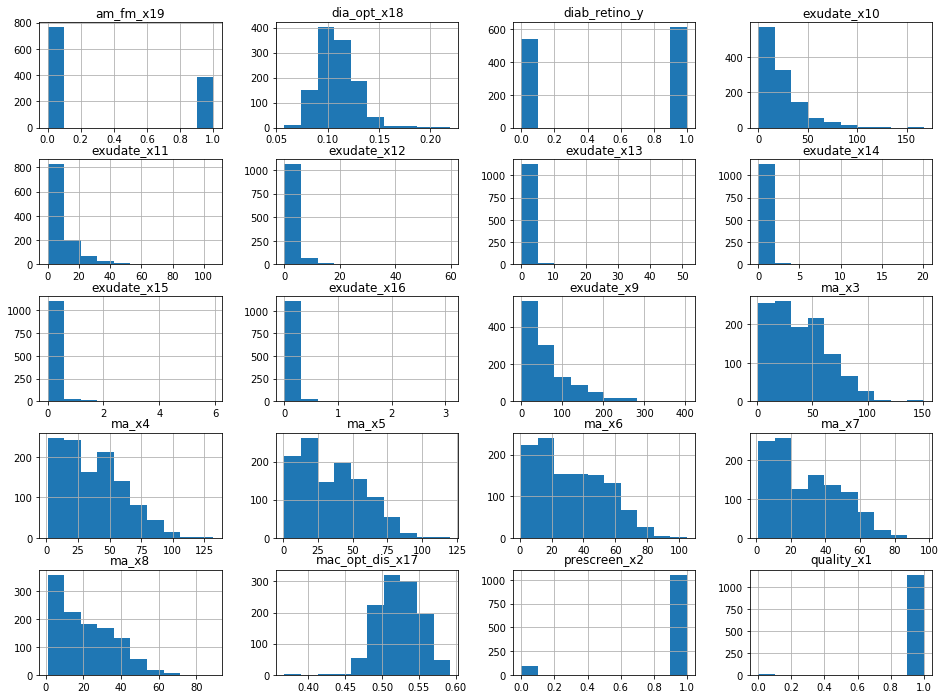

```python
# Display histograms
import matplotlib.pyplot as plt
%matplotlib inline

#DataVisualization
retinopathy.hist(figsize=(16,12)) # it can be seen that class is almost perfectly balanced

# Note that the quality_3 feature is not apporting new information
plt.show()
```

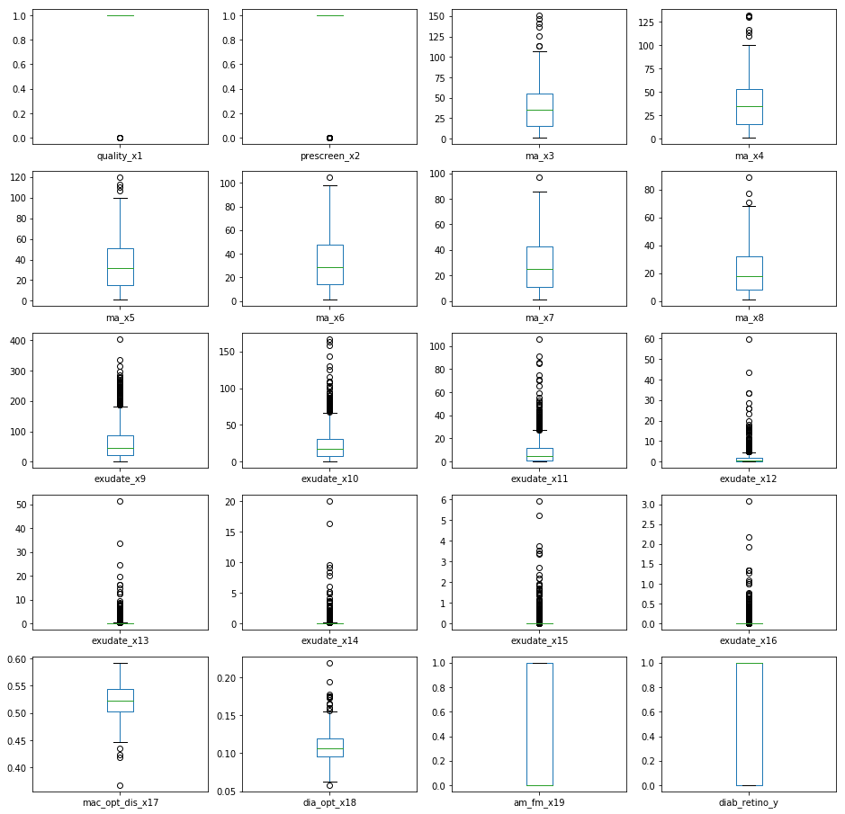

```python
# Create box plots
import matplotlib.pyplot as plt
%matplotlib inline

retinopathy.plot(kind= 'box' , subplots=True, layout=(5,4), sharex=False, sharey=False, figsize=(16,16))

plt.show()
```

### Correlation matrix with visualisation

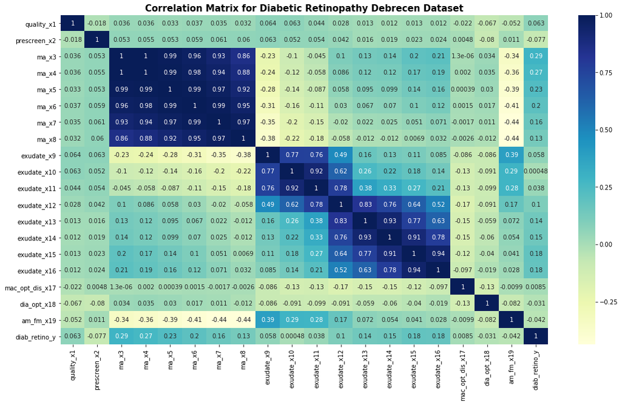

```python
# Correlation between pairs of features before any imputation

import matplotlib.pyplot as plt
import seaborn as sns

%matplotlib inline


fig=plt.figure(figsize=(18, 10))

corr = retinopathy.corr()
ax = sns.heatmap(corr, annot = True, cmap="YlGnBu")

plt.setp(ax.axes.get_xticklabels(), rotation=90)
plt.title('Correlation Matrix for Diabetic Retinopathy Debrecen Dataset', fontsize=15, fontweight='bold')
plt.show()
```

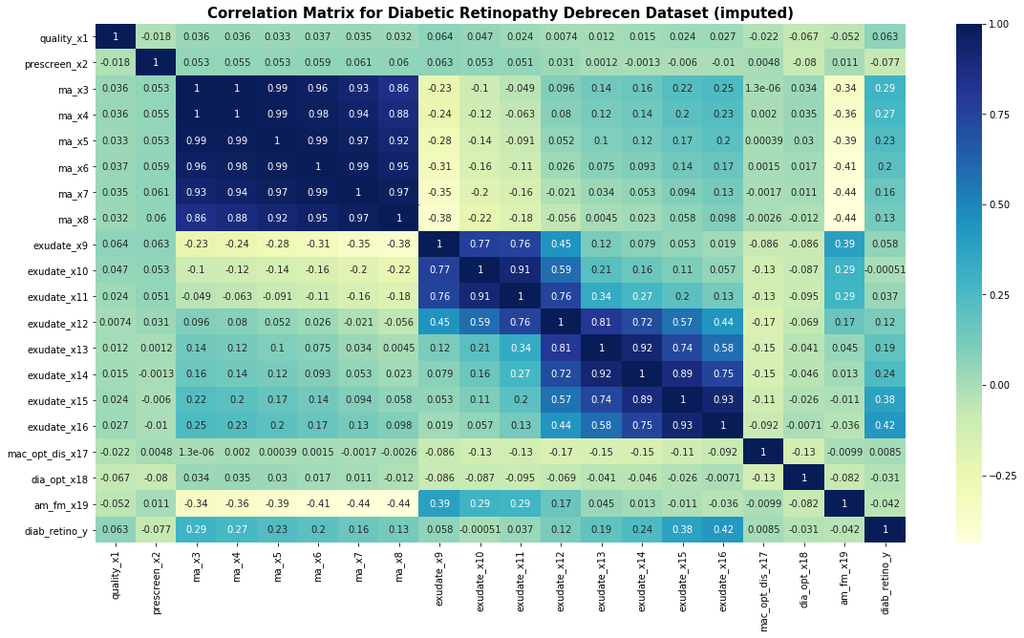

```python
# Correlation between pairs of features after median imputation
import matplotlib.pyplot as plt
import seaborn as sns

%matplotlib inline

fig=plt.figure(figsize=(19, 10))

corr = retinopathy_impute.corr() # correlation excessively increased from x14-x16 (high proportion of zeros)
ax = sns.heatmap(corr, annot = True, cmap="YlGnBu")

plt.setp(ax.axes.get_xticklabels(), rotation=90)
plt.title('Correlation Matrix for Diabetic Retinopathy Debrecen Dataset (imputed)',fontsize=15, fontweight='bold')
plt.show()
```

# Exploring feature space

### 3 dimensional representation

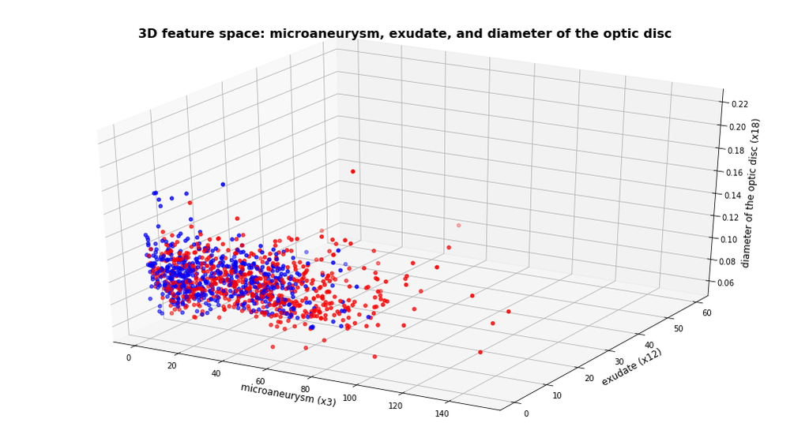

```python
import matplotlib.pyplot as plt
from mpl_toolkits.mplot3d import Axes3D
%matplotlib inline

df = retinopathy
feature1 = df['ma_x3'].values
feature2 = df['exudate_x12'].values
feature3 = df['dia_opt_x18'].values

df['diab_retino_y']=df['diab_retino_y'].astype('str')

c = df['diab_retino_y'].values
df['diab_retino_y'] = df['diab_retino_y'].astype('int')
c[c=='0'] = 'b' #negative diagnosis diabetes
c[c=='1'] = 'r' #positive diagnosis diabetes

fig = plt.figure(figsize=(18,10))
ax = fig.add_subplot(111, projection='3d')
ax.scatter(feature1, feature2, feature3, c=c)
ax.set_xlabel('microaneurysm (x3)', fontsize=12)
ax.set_ylabel('exudate (x12)',fontsize=12)
ax.set_zlabel('diameter of the optic disc (x18)', fontsize=12)

plt.title('3D feature space: microaneurysm, exudate, and diameter of the optic disc',fontsize=16, fontweight='bold')

plt.savefig('3d_feature.jpeg')

# There is not clear separation
plt.show()
```

There was not evident separation region and thus a 2-dimensional may be more appropiate using different features

### 2 dimensional representation

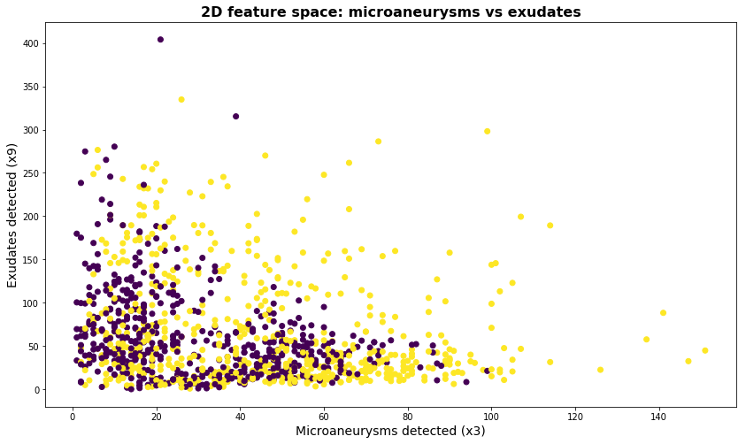

```python
from matplotlib import pyplot as plt
%matplotlib inline

plt.figure(figsize=(14,8))
plt.scatter(df.ma_x3, df.exudate_x9, c=df.diab_retino_y) # plot the feature space with color coded classes

plt.title('2D feature space: microaneurysms vs exudates',fontsize=16, fontweight='bold')
plt.xlabel('Microaneurysms detected (x3)', fontsize=14)
plt.ylabel('Exudates detected (x9)', fontsize=14)

plt.savefig('2d_feature.jpeg')
plt.show()
```

# Data preprocessing

### Balance or imbalance?

```python
# Show balance or imbalance (assuming no missing data in the class)
X, y = retinopathy.iloc[:, 0:19].values, retinopathy.iloc[:, -1].values # -1 indexing

print ("instances:", y.size)
print ("class label 0:", y[y==0].size)
print ("class label 1:", y[y==1].size)
```

```
('instances:', 1151)
('class label 0:', 540)
('class label 1:', 611)
```

### Encoding class label

Dataset had already the right format, binary features and class were already specified as integer. Microaneurysm features were also integer type. The rest of features as float. The routine below could have been used in a different scenario.

```python
# from sklearn.preprocessing import LabelEncoder

# X = X.astype(float)
# y = y.astype(int)

# le = LabelEncoder()
# y = le.fit_transform(y)
# le.classes_
```

### Splitting the data

```python
# Splitting data into random train and test subsets: 70% training and 30% test subsets
from sklearn.model_selection  import train_test_split
splitRatio = 0.7

X_train, X_test, y_train, y_test = train_test_split(X, y, test_size=(1-splitRatio), random_state=1)
```

```python
# Check the dimensionality
print 'X_train dimensions: ', X_train.shape
print 'y_train dimensions: ', y_train.shape
print 'X_test dimensions: ', X_test.shape
print 'y_test dimensions: ', y_test.shape
```

```
X_train dimensions:  (805, 19)
y_train dimensions:  (805,)
X_test dimensions:  (346, 19)
y_test dimensions:  (346,)
```

### Function that encapsulates prevous 2 steps (function 1)

```python
# Function 1 --> function that prepares a training-testing dataset for the Diabetic Retinopathy Debrecen dataset
# It includes: turning data into a an numpy array, splitting accordingly and checking dimensionality
# It requres a dataframe and a column label list
def new_train_test_set(df, features):
    from sklearn.preprocessing import LabelEncoder
    from sklearn.model_selection import train_test_split

    # Turn data and feature and class values into numpy array
    n_feature = len(features)-1
    X_new, y_new = df.iloc[:, 0:n_feature].values, df.iloc[:, -1].values # -1 indexing

    print ("Instances: " + str( y_new.size))
    print ("Class label 0: " + str( y_new[y_new==0].size))
    print ("Class label 1: " + str(y_new[y_new==1].size))

    # Split into features and class
    X_train_temp, X_test_temp, y_train_temp, y_test_temp = \
                            train_test_split(X_new, y_new, test_size=0.30, random_state=1)

    # Check the dimensionality
    print ('Data set:')
    print ('X_train dimensions: ' + str(X_train_temp.shape))
    print ('y_train dimensions: ' + str(y_train_temp.shape))
    print ('X_test dimensions: ' + str( X_test_temp.shape))
    print ('y_test dimensions: ' + str( y_test_temp.shape))

    return X_train_temp, X_test_temp, y_train_temp, y_test_temp
```

### Scaling

Instead of standardising features by removing the mean and scaling to unit variance, it was removed the median and scaled the data according to the interquantile range (IQR). This a demostration of how RobustScaler works. Note: for demo purposes, this was performed for the whole dataframe, but in reality it will be only applied to the training set.

```python
# Carry out robust scaling
from sklearn.preprocessing import RobustScaler
retino2 = RobustScaler(quantile_range=(25, 75)).fit_transform(retinopathy)
```

```python
# Show Scale features in the new dataframe
retino_scale = pd.DataFrame(data=retino2,columns=cols1)
retino_scale.head()
```

|  | quality_x1 | prescreen_x2 | ma_x3 | ma_x4 | ma_x5 | ma_x6 | ma_x7 | ma_x8 | exudate_x9 | exudate_x10 | exudate_x11 | exudate_x12 | exudate_x13 | exudate_x14 | exudate_x15 | exudate_x16 | mac_opt_dis_x17 | dia_opt_x18 | am_fm_x19 | diab_retino_y |
| --- | --- | --- | --- | --- | --- | --- | --- | --- | --- | --- | --- | --- | --- | --- | --- | --- | --- | --- | --- | --- |
| 0 | 0.0 | 0.0 | -0.333333 | -0.351351 | -0.277778 | -0.294118 | -0.21875 | -0.166667 | 0.086165 | 0.031583 | 0.080573 | 0.155933 | -0.018838 | 0.138100 | 0.811879 | 1.018696 | -0.891962 | -0.277320 | 1.0 | -1.0 |
| 1 | 0.0 | 0.0 | -0.282051 | -0.297297 | -0.277778 | -0.323529 | -0.28125 | -0.208333 | 0.205407 | 0.289389 | -0.104399 | -0.136213 | -0.095570 | 0.061092 | 0.807740 | 1.013503 | -0.058803 | 1.588391 | 0.0 | -1.0 |
| 2 | 0.0 | 0.0 | 0.692308 | 0.675676 | 0.750000 | 0.735294 | 0.68750 | 0.625000 | 0.176742 | 0.468875 | 0.785715 | 2.373493 | 7.145713 | 9.666922 | 8.654180 | 2.010906 | 0.186110 | 0.921528 | 0.0 | 0.0 |
| 3 | 0.0 | 0.0 | 0.512821 | 0.486486 | 0.583333 | 0.617647 | 0.56250 | 0.541667 | -0.057710 | 0.060255 | 0.446426 | 1.410035 | 4.261528 | 7.044902 | 1.583816 | 0.397559 | -0.980632 | 0.343267 | 0.0 | -1.0 |
| 4 | 0.0 | 0.0 | 0.230769 | 0.243243 | 0.333333 | 0.352941 | 0.43750 | 0.375000 | -0.400150 | -0.362372 | -0.381551 | -0.263480 | -0.115903 | -0.040416 | 0.000000 | 0.000000 | -1.160690 | 0.712382 | 0.0 | 0.0 |

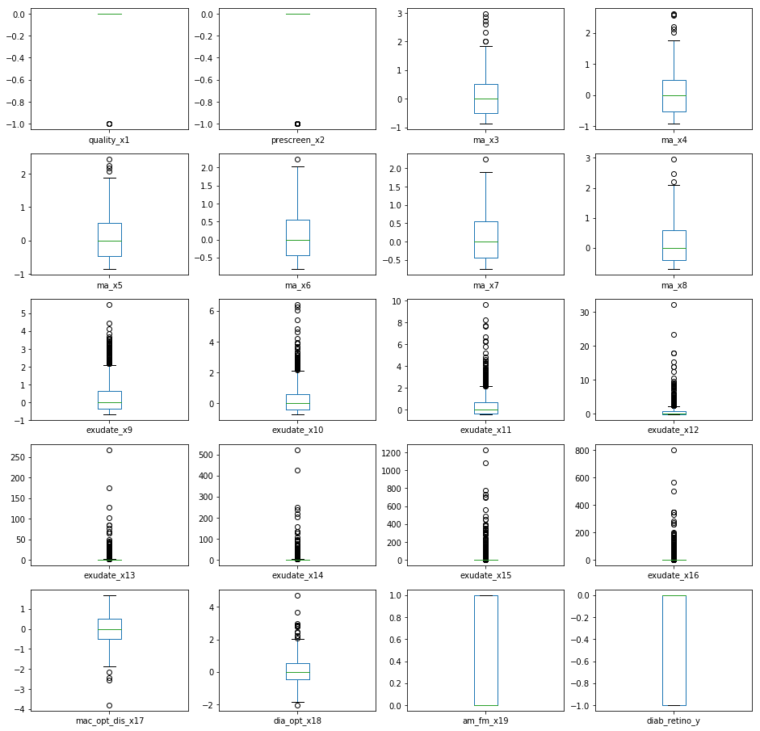

```python
# Plot the dataset, median=0 and scaled according to IQR
import matplotlib.pyplot as plt
%matplotlib inline

retino_scale.plot(kind= 'box' , subplots=True, layout=(5,4), sharex=False, sharey=False, figsize=(16,16))

plt.show()
```

## Selecting possible features: feature importance with random forest

```
 1) ma_x3                          0.088253
 2) exudate_x9                     0.087646
 3) exudate_x10                    0.072340
 4) exudate_x11                    0.066907
 5) exudate_x12                    0.064892
 6) mac_opt_dis_x17                0.063542
 7) dia_opt_x18                    0.063303
 8) ma_x4                          0.062874
 9) exudate_x15                    0.059826
10) ma_x5                          0.054837
11) ma_x7                          0.053170
12) ma_x8                          0.052967
13) ma_x6                          0.052102
14) exudate_x13                    0.049338
15) exudate_x14                    0.045898
16) exudate_x16                    0.044544
17) prescreen_x2                   0.009019
18) am_fm_x19                      0.008480
19) quality_x1                     0.000062
```

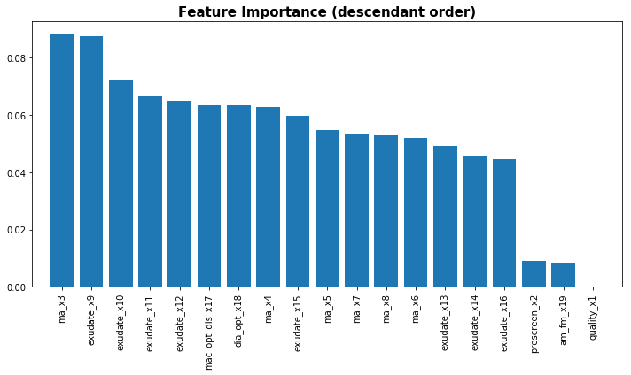

```python
from sklearn.ensemble import RandomForestClassifier
from matplotlib import pyplot as plt
%matplotlib inline
# Assessment of features adapted from (Raschka and Mirjalili, 2017)

# Create again original train-test data set
X_train, X_test, y_train, y_test = train_test_split(X, y, test_size=(1-splitRatio), random_state=1)

feature_labels = retinopathy.columns[0:19]

# Train the forest of 1000 trees in the data set
forest = RandomForestClassifier(n_estimators=1000, random_state=1)

# Create a forest of trees from the training set
forest.fit(X_train, y_train)
importances = forest.feature_importances_

# Array of indices sorted
indices = np.argsort(importances)[::-1]

# Labels in descendant order
for f in range(X_train.shape[1]):
    print("%2d) %-*s %f" % (f + 1, 30, feature_labels[indices[f]], importances[indices[f]]))

# Create plot
plt.figure(figsize=(10,6))
plt.bar(range(X_train.shape[1]), importances[indices],align='center')

# Create labels
plt.title('Feature Importance (descendant order)', fontsize=15, fontweight='bold')
plt.xticks(range(X_train.shape[1]), feature_labels[indices], rotation=90)
plt.xlim([-1, X_train.shape[1]])

# Keep tight the plot
plt.tight_layout()

# Show the plot
plt.show()
```

The least discriminative features in the 1000 decision trees, as seen in the plot above, are quality assessment (quality_x1), prescreen (prescreen_x2) and am/fm-based classification (am_fm_x19). However, some of the most discriminative features are highly correlated to each other as can be seen in the correlation matrix in section "exploring relations".

## Choosing a scoring parameter for model evaluation

```python
from sklearn.metrics.scorer import SCORERS
print(SCORERS.keys())
```

[output not shown]

'roc_auc' can be used to calculate the Area Under the Receiver Operating Characteristic Curve (ROC AUC). It is a score restricted to binary classification problems: http://scikit-learn.org/stable/modules/model_evaluation.html#scoring-parameter

# Exploring different KNN pipelines (before tuning)

```python
# Spliting data 16 features
# List of features and class:
feature_16 = ["ma_x3", "ma_x4", "ma_x5", "ma_x6", "ma_x7", "ma_x8", "exudate_x9", "exudate_x10",
               "exudate_x11", "exudate_x12", "exudate_x13", "exudate_x14", "exudate_x15",
               "exudate_x16", "mac_opt_dis_x17", "dia_opt_x18", "diab_retino_y"]

# Dataframe
retino_16 = retinopathy[feature_16]

# Split data and get training and testing set
X_train1, X_test1, y_train1, y_test1 = new_train_test_set(retino_16, feature_16) # call function 1
```

```
Instances: 1151
Class label 0: 540
Class label 1: 611
Data set:
X_train dimensions: (805, 16)
y_train dimensions: (805,)
X_test dimensions: (346, 16)
y_test dimensions: (346,)
```

```python
# Define pipelines
pipe1_knn = Pipeline([['KNN', KNeighborsClassifier()]])
pipe2_knn = Pipeline([['sc', StandardScaler()], ['clf', KNeighborsClassifier()]])
pipe3_knn = Pipeline([['rc', RobustScaler(quantile_range=(25, 75))], ['clf', KNeighborsClassifier()]])
```

```python
# Create an array of estimators
estimators =[]
estimators.append(('KNN_0', pipe1_knn))
estimators.append(('KNN_standar', pipe2_knn))
estimators.append(('KNN_robust', pipe3_knn))
```

```python
# Make labels accordingly
clf_labels_knn = ['k-Nearest Neighbors basal','k-Nearest Neighbors standardised','k-Nearest Neighbors robust']
```

```python
# Estimate  Receiver Operating Characteristic Area Under the Curve scores
all_knn_clf = [pipe1_knn, pipe2_knn, pipe3_knn]

for clf, label in zip(all_knn_clf, clf_labels_knn):
    scores = cross_val_score(estimator=clf, X=X_train1, y=y_train1, cv=10, scoring='roc_auc')
    print("KNN Model Training ROC AUC score mean(sd): %0.4f (+/- %0.4f) [%s]" % (scores.mean(), scores.std(), label))
```

```
KNN Model Training ROC AUC score mean(sd): 0.7274 (+/- 0.0644) [k-Nearest Neighbors basal]
KNN Model Training ROC AUC score mean(sd): 0.6620 (+/- 0.0774) [k-Nearest Neighbors standardised]
KNN Model Training ROC AUC score mean(sd): 0.6648 (+/- 0.0443) [k-Nearest Neighbors robust]
```

The difference in the mean area under the ROC curve between removing the mean and scaling to unit variance (StandardScaler), and removing the median and scaling to the interquartile range (RobustScaler) was less than 0.02 on the training models. The following pipelines will be used for tuning: pipe2_knn & pipe3_knn

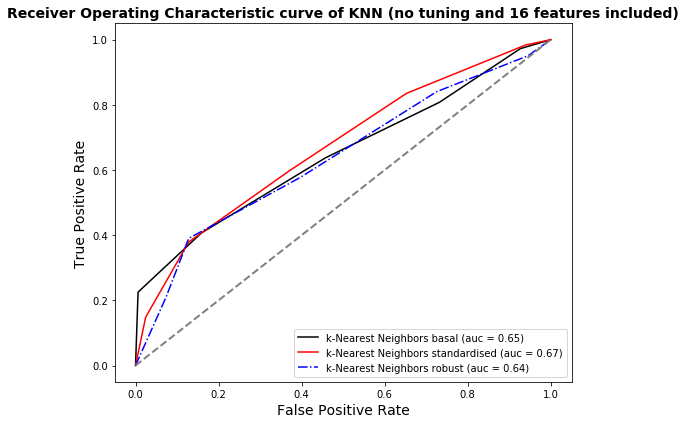

```python
# Plot  Receiver Operating Characteristic Curves

from matplotlib import pyplot as plt

fig=plt.figure(figsize=(9, 6))

colors = ['black', 'red', 'blue', 'lightseagreen', 'darkblue', 'orange', 'salmon','m', 'green']
# palette colour: https://matplotlib.org/examples/color/named_colors.html
linestyles = ['-', '-', '-.', '-', '--', '-', ':', '--', '-']
for clf, label, clr, ls in zip(all_knn_clf, clf_labels_knn, colors, linestyles):
    # assuming the label of the positive class is 1
    y_pred = clf.fit(X_train1, y_train1).predict_proba(X_test1)[:, 1]
    fpr, tpr, thresholds = roc_curve(y_true=y_test1, y_score=y_pred)
    roc_auc = auc(x=fpr, y=tpr)
    plt.plot(fpr, tpr, color=clr, linestyle=ls, label='%s (auc = %0.2f)' % (label, roc_auc))

plt.legend(loc='lower right')
plt.plot([0, 1], [0, 1], linestyle='--', color='gray', linewidth=2)
plt.xlim([-0.05, 1.05])
plt.ylim([-0.05, 1.05])

# Title and labels for axes:
plt.title("Receiver Operating Characteristic curve of KNN (no tuning and 16 features included)",
          fontsize=14, fontweight='bold')
plt.xlabel('False Positive Rate', fontsize=14)
plt.ylabel('True Positive Rate', fontsize=14)

plt.tight_layout()
plt.show()
```

## Tune KNN Algorithms

```python
# Function that computes a KNN parameter tuning, it uses pipeline and grid search
def knn_tuning(X_train_tun, y_train_tun, param_range_tun, pipe_knn):
    from sklearn.neighbors import KNeighborsClassifier as KNN

    num_folds=10

#     pipe_knn = Pipeline([('scl', StandardScaler()),
#                          ('clf', KNeighborsClassifier())])

    scores = cross_val_score(estimator=pipe_knn,
                         X=X_train_tun,
                         y=y_train_tun,
                          scoring='roc_auc',
                         cv=num_folds,
                         n_jobs=1)
    print('--> Model Training Accuracy: %.3f +/- %.3f' %(np.mean(scores), np.std(scores)))

    #Tune Hyperparameters
    weight=  ['uniform', 'distance']
    metric = ['euclidean', 'manhattan','chebyshev']
    param_grid = [{'clf__n_neighbors': param_range_tun,'clf__weights': weight, 'clf__metric':metric}]

    # Instantiate the grid
    grid = GridSearchCV(estimator=pipe_knn,
                    param_grid=param_grid,
                    cv=num_folds,
                    scoring='roc_auc',
                    n_jobs=-1)

    gs_knn = grid.fit(X_train_tun, y_train_tun)
    print'--> Tuned Parameters Best Score: ',gs_knn.best_score_
    print'--> Best Parameters: \n',gs_knn.best_params_
    return gs_knn
```

## Case 1 (pipe2_knn): StandardScaler 16 features

```python
# Case 1: tuning using 16 features,
# List of features and class:
# feature_16 = ["ma_x3", "ma_x4", "ma_x5", "ma_x6", "ma_x7", "ma_x8", "exudate_x9", "exudate_x10",
#                "exudate_x11", "exudate_x12", "exudate_x13", "exudate_x14", "exudate_x15",
#                "exudate_x16", "mac_opt_dis_x17", "dia_opt_x18", "diab_retino_y"]
# KNN grid search, max n_neighbour:30
print
print 'KNN classifier:'
param_range = range(3, 30, 2) # only odd numbers for kNN
gs_knn_1 = knn_tuning(X_train1, y_train1, param_range, pipe2_knn)
```

```
KNN classifier:
--> Model Training Accuracy: 0.662 +/- 0.077
--> Tuned Parameters Best Score:  0.715163708116
--> Best Parameters:
{'clf__weights': 'distance', 'clf__metric': 'manhattan', 'clf__n_neighbors': 27}
```

```python
#Get Final Scores
clf_knn = gs_knn_1.best_estimator_
clf_knn.fit(X_train1, y_train1)
scores = cross_val_score(estimator=clf_knn,
                         X=X_train1,
                         y=y_train1,
                         cv=10,
                         scoring='roc_auc',
                         n_jobs=1)
print('--> Final KNN Model Training ROC UAC score: %.3f +/- %.3f' %(np.mean(scores), np.std(scores)))

print('--> Final KNN ROC AUC score on Test set: %.5f' % clf_knn.score(X_test1,y_test1))
```

```
--> Final KNN Model Training ROC UAC score: 0.715 +/- 0.059
--> Final KNN ROC AUC score on Test set: 0.61561
```

```python
# Get confusion matrix, precision, recall and f1 scores
# clf_knn.fit(X_train, y_train)
y_pred1 = clf_knn.predict(X_test1)

print(confusion_matrix(y_test1, y_pred1))
print(classification_report(y_test1, y_pred1))
```

```
[[114  50]
 [ 83  99]]
             precision    recall  f1-score   support

          0       0.58      0.70      0.63       164
          1       0.66      0.54      0.60       182

avg / total       0.62      0.62      0.61       346
```

## Case 2 (pipe3_knn): RobustScaler 16 features

```python
# Dataframe
# retino_all = retinopathy[feature_all]

# Split data and get training and testing set
# X_train1, X_test1, y_train1, y_test1 = new_train_test_set(retino_all,feature_all)

# KNN grid search, max n_neighbour:30

print
print 'KNN classifier:'
param_range = range(3, 30, 2) # only odd numbers for kNN
gs_knn_2 = knn_tuning(X_train1, y_train1, param_range, pipe3_knn)
```

```
KNN classifier:
--> Model Training Accuracy: 0.665 +/- 0.044
--> Tuned Parameters Best Score:  0.718689123189
--> Best Parameters:
{'clf__weights': 'distance', 'clf__metric': 'manhattan', 'clf__n_neighbors': 21}
```

```python
clf_knn = gs_knn_2.best_estimator_
#Get Final Scores
clf_knn.fit(X_train1, y_train1)
scores = cross_val_score(estimator=clf_knn,
                         X=X_train1,
                         y=y_train1,
                         cv=10,
                         scoring='roc_auc',
                         n_jobs=1)
print('--> Final KNN Model Training ROC UAC score: %.3f +/- %.3f' %(np.mean(scores), np.std(scores)))

print('--> Final KNN ROC AUC score on Test set: %.5f' % clf_knn.score(X_test1,y_test1))
```

```
--> Final KNN Model Training ROC UAC score: 0.719 +/- 0.039
--> Final KNN ROC AUC score on Test set: 0.63873
```

```python
# Get confusion matrix, precision, recall and f1 scores
# clf_knn.fit(X_train, y_train)
y_pred2 = clf_knn.predict(X_test1)

print(confusion_matrix(y_test1, y_pred2))
print(classification_report(y_test1, y_pred2))
```

```
[[109  55]
 [ 70 112]]
             precision    recall  f1-score   support

          0       0.61      0.66      0.64       164
          1       0.67      0.62      0.64       182

avg / total       0.64      0.64      0.64       346
```

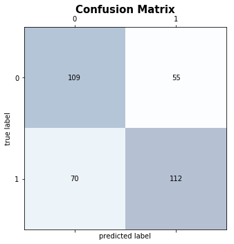

```python
# Show confusion matrix and evaluation measures derivates
y_pred2 = clf_knn.predict(X_test1)

confmat = confusion_matrix(y_test1, y_pred2)

# Draw Confusion matrix
%matplotlib inline

fig, ax = plt.subplots(figsize=(5, 5))
ax.matshow(confmat, cmap=plt.cm.Blues, alpha=0.3)
for i in range(confmat.shape[0]):
    for j in range(confmat.shape[1]):
        ax.text(x=j, y=i, s=confmat[i, j], va='center', ha='center')

plt.title('Confusion Matrix',
          fontsize=15, fontweight='bold')
plt.xlabel('predicted label')
plt.ylabel('true label')

plt.tight_layout()
plt.show()
```

## Plotting ROC curves

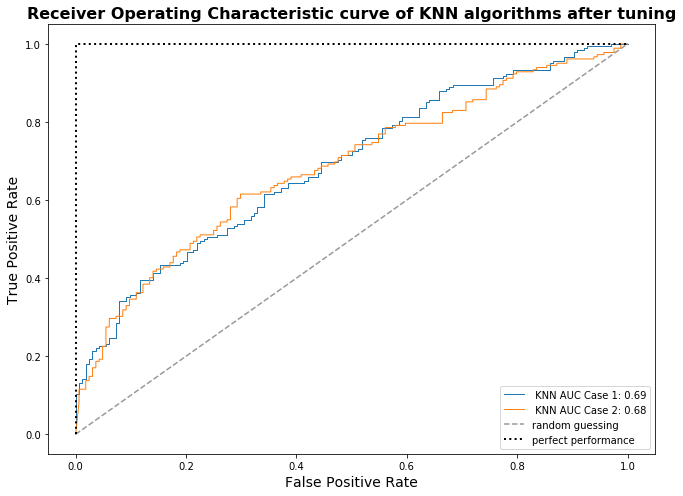

```python
#### import matplotlib.pyplot as plt
%matplotlib inline

from sklearn.metrics import roc_curve, auc
from sklearn.metrics import roc_auc_score

fig=plt.figure(figsize=(10, 7))
all_tpr = []

# Models:

# Case 1
gs_knn_1
probas = gs_knn_1.predict_proba(X_test1)
fpr1, tpr1, thresholds = roc_curve(y_test1, probas[:, 1], pos_label=1)
roc_auc1 = auc(fpr1, tpr1)
current_auc1 = str('%.2f' %roc_auc1)
plt.plot(fpr1,
         tpr1,
         lw=1,
         label= str(' KNN AUC Case 1: ' + current_auc1))

# Case 2
gs_knn_2
probas = gs_knn_2.predict_proba(X_test1)
fpr2, tpr2, thresholds = roc_curve(y_test1, probas[:, 1], pos_label=1)
roc_auc2 = auc(fpr2, tpr2)
current_auc2 = str('%.2f' %roc_auc2)
plt.plot(fpr2,
         tpr2,
         lw=1,
         label= str(' KNN AUC Case 2: ' + current_auc2))


# Plot diagonal
plt.plot([0, 1],
         [0, 1],
         linestyle='--',
         color=(0.6, 0.6, 0.6),
         label='random guessing')

# Plot perfect case
plt.plot([0, 0, 1],
         [0, 1, 1],
         lw=2,
         linestyle=':',
         color='black',
         label='perfect performance')

plt.xlim([-0.05, 1.05])
plt.ylim([-0.05, 1.05])
# plt.xlabel('false positive rate')
# plt.ylabel('true positive rate')
# plt.title('Receiver Operator Characteristic')
plt.legend(loc="lower right")


# Title and labels for axes:
plt.title("Receiver Operating Characteristic curve of KNN algorithms after tuning", fontsize=16, fontweight='bold')
plt.xlabel('False Positive Rate', fontsize=14)
plt.ylabel('True Positive Rate', fontsize=14)

plt.tight_layout()
plt.show()
```

# Exploring different SVM pipelines (before tuning)

```python
# Spliting data 16 features
# List of features and class:
feature_16 = ["ma_x3", "ma_x4", "ma_x5", "ma_x6", "ma_x7", "ma_x8", "exudate_x9", "exudate_x10",
               "exudate_x11", "exudate_x12", "exudate_x13", "exudate_x14", "exudate_x15",
               "exudate_x16", "mac_opt_dis_x17", "dia_opt_x18", "diab_retino_y"]

# Dataframe
retino_16 = retinopathy[feature_16]

# Split data and get training and testing set
X_train1, X_test1, y_train1, y_test1 = new_train_test_set(retino_16, feature_16) # call function 1
```

```
Instances: 1151
Class label 0: 540
Class label 1: 611
Data set:
X_train dimensions: (805, 16)
y_train dimensions: (805,)
X_test dimensions: (346, 16)
y_test dimensions: (346,)
```

```python
# Define pipelines
pipe1_svc = Pipeline([['SVC', SVC(probability=True)]])
pipe2_svc = Pipeline([['sc', StandardScaler()], ['clf', SVC(probability=True)]])
pipe3_svc = Pipeline([['sc', RobustScaler(quantile_range=(25, 75))], ['clf', SVC(probability=True)]])
```

```python
# Create an array of estimators
estimators =[]
estimators.append(('SVC_0', pipe1_svc))
estimators.append(('SVC_standar', pipe2_svc))
estimators.append(('SVC_robust', pipe3_svc))
```

```python
# Make labels accordingly
# clf_labels = ['Support Vector Machine standardised']
clf_labels = ['Support Vector Machine basal','Support Vector Machine standardised', 'Support Vector Machine robust scale']
```

```python
# Estimate  Receiver Operating Characteristic Area Under the Curve scores
all_clf = [pipe1_svc, pipe2_svc, pipe3_svc]
# all_clf = [pipe2_svc]

for clf, label in zip(all_clf, clf_labels):
    scores = cross_val_score(estimator=clf, X=X_train1, y=y_train1, cv=10, scoring='roc_auc')
    print("SVM Model Training ROC AUC score mean(sd): %0.4f (+/- %0.4f) [%s]" % (scores.mean(), scores.std(), label))
```

```
SVM Model Training ROC AUC score mean(sd): 0.6362 (+/- 0.0710) [Support Vector Machine basal]
SVM Model Training ROC AUC score mean(sd): 0.7623 (+/- 0.0486) [Support Vector Machine standardised]
SVM Model Training ROC AUC score mean(sd): 0.7194 (+/- 0.0410) [Support Vector Machine robust scale]
```

The difference in the mean area under the ROC curve between removing the mean and scaling to unit variance (StandardScaler), and removing the median and scaling to the interquartile range (RobustScaler) was less than 0.05 on the training models. The following pipelines will be used for tuning: pipe2_svc & pipe3_svc

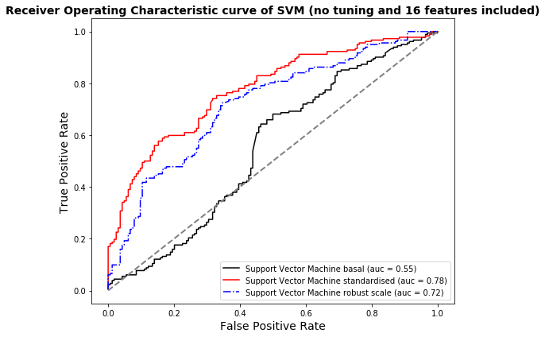

```python
# Plot  Receiver Operating Characteristic Curves

from matplotlib import pyplot as plt

fig=plt.figure(figsize=(9, 6))

colors = ['black', 'red', 'blue', 'lightseagreen', 'darkblue', 'orange', 'salmon','m', 'green']
# palette colour: https://matplotlib.org/examples/color/named_colors.html
linestyles = ['-', '-', '-.', '-', '--', '-', ':', '--', '-']
for clf, label, clr, ls in zip(all_clf, clf_labels, colors, linestyles):
    # assuming the label of the positive class is 1
    y_pred = clf.fit(X_train1, y_train1).predict_proba(X_test1)[:, 1]
    fpr, tpr, thresholds = roc_curve(y_true=y_test1, y_score=y_pred)
    roc_auc = auc(x=fpr, y=tpr)
    plt.plot(fpr, tpr, color=clr, linestyle=ls, label='%s (auc = %0.2f)' % (label, roc_auc))

plt.legend(loc='lower right')
plt.plot([0, 1], [0, 1], linestyle='--', color='gray', linewidth=2)
plt.xlim([-0.05, 1.05])
plt.ylim([-0.05, 1.05])

# Title and labels for axes:
plt.title("Receiver Operating Characteristic curve of SVM (no tuning and 16 features included)",
          fontsize=14, fontweight='bold')
plt.xlabel('False Positive Rate', fontsize=14)
plt.ylabel('True Positive Rate', fontsize=14)

plt.tight_layout()
plt.show()
```

## Tune SVM Algorithms

```python
# Function that computes a SVM parameter tuning, it uses pipeline and grid search
def svc_tuning_standard2(X_train_tun, y_train_tun, pipeline_svc2):
    # number of equal sized subsamples
    num_folds = 10

    # Pipeline
    pipe_svc_temp = pipeline_svc2

    # Get scores from the k-fold cross-validation computing the...
    # Area Under the Receiver Operating Characteristic Curve (ROC AUC) from prediction scores
    # Score restricted to binary classification tasks
    # http://scikit-learn.org/stable/modules/model_evaluation.html#scoring-parameter
    scores = cross_val_score(estimator=pipe_svc_temp,
                         X=X_train_tun,
                         y=y_train_tun,
                         scoring='roc_auc',
                         cv=num_folds,
                         n_jobs=-1)# number of jobs to run in parallel: -1 indicates all CPUs
    print('Model Training ROC AUC: %.3f +/- %.3f' %(np.mean(scores), np.std(scores)))

    # Tuning Hyperparameters by grid search: classify using a Linear, RBF ans Sigmoid Kernels, varying C and gamma parameters
    param_range = [0.001, 0.01, 0.1, 1.0, 10.0, 100.0, 1000.0]
    param_grid = [{'clf__C': param_range,'clf__kernel': ['linear']},
              {'clf__C': param_range,'clf__gamma': param_range,
               'clf__kernel': ['rbf']},
              {'clf__C': param_range,'clf__gamma': param_range,
               'clf__kernel': ['sigmoid']}]


    # SVC grid search
    gs_svc_temp = GridSearchCV(estimator=pipe_svc_temp,
                      param_grid=param_grid,
                      scoring='roc_auc',
                      cv=num_folds,
                      n_jobs=-1) # number of jobs to run in parallel: -1 indicates all CPUs

    # Fit the Support Vector Classification model according to the given training data
    gs_svc_temp = gs_svc_temp.fit(X_train_tun, y_train_tun)

    # Print results
    print 'Tuned Parameters Best Score: ',gs_svc_temp.best_score_
    print 'Best Parameters: \n',gs_svc_temp.best_params_
    return gs_svc_temp
```

## Case 3 (pipe2_svc): StandardScaler 16 features

```python
# Case 3: tuning using 16 features
# List of features and class:
# feature_16 = ["ma_x3", "ma_x4", "ma_x5", "ma_x6", "ma_x7", "ma_x8", "exudate_x9", "exudate_x10",
#                "exudate_x11", "exudate_x12", "exudate_x13", "exudate_x14", "exudate_x15",
#                "exudate_x16", "mac_opt_dis_x17", "dia_opt_x18", "diab_retino_y"]

gs_svc_1 = svc_tuning_standard2(X_train1, y_train1, pipe2_svc )
```

```
Model Training ROC AUC: 0.762 +/- 0.049
Tuned Parameters Best Score:  0.835278710379
Best Parameters:
{'clf__gamma': 0.01, 'clf__C': 1000.0, 'clf__kernel': 'rbf'}
```

```python
# Get Final Area Under the Receiver Operating Characteristic Curve (ROC AUC) scores
clf_svc = gs_svc_1.best_estimator_
clf_svc.fit(X_train1, y_train1)
scores = cross_val_score(estimator=clf_svc,
                         X=X_train1,
                         y=y_train1,
                         cv=10,
                         scoring='roc_auc',
                         n_jobs=1)
print('--> Final SVM Model Training ROC UAC score: %.3f +/- %.3f' %(np.mean(scores), np.std(scores)))

print('--> Final SVM ROC AUC score on Test set: %.5f' % clf_svc.score(X_test1,y_test1))
```

```
--> Final SVM Model Training ROC UAC score: 0.835 +/- 0.034
--> Final SVM ROC AUC score on Test set: 0.73699
```

```python
# Get confusion matrix, precision, recall and f1 scores
clf_svc.fit(X_train1, y_train1)
y_pred1 = clf_svc.predict(X_test1)

print(confusion_matrix(y_test1, y_pred1))
print(classification_report(y_test1, y_pred1))
```

```
[[127  37]
 [ 54 128]]
             precision    recall  f1-score   support

          0       0.70      0.77      0.74       164
          1       0.78      0.70      0.74       182

avg / total       0.74      0.74      0.74       346
```

## Case 4 (pipe3_svc): RobustScaler 16 features

```python
# Case 4: tuning using 16 features, pipeline 3
gs_svc_2 = svc_tuning_standard2(X_train1, y_train1, pipe3_svc)
```

```
Model Training ROC AUC: 0.719 +/- 0.041
Tuned Parameters Best Score:  0.821413729091
Best Parameters:
{'clf__C': 10.0, 'clf__kernel': 'linear'}
```

```python
# Get Final Area Under the Receiver Operating Characteristic Curve (ROC AUC) scores
clf_svc = gs_svc_2.best_estimator_
#Get Final Scores
clf_svc.fit(X_train1, y_train1)
scores = cross_val_score(estimator=clf_svc,
                         X=X_train1,
                         y=y_train1,
                         cv=10,
                         scoring='roc_auc',
                         n_jobs=1)
print('--> Final SVM Model Training ROC UAC score: %.3f +/- %.3f' %(np.mean(scores), np.std(scores)))

print('--> Final SVM ROC AUC score on Test set: %.5f' % clf_svc.score(X_test1,y_test1))
```

```
--> Final SVM Model Training ROC UAC score: 0.822 +/- 0.045
--> Final SVM ROC AUC score on Test set: 0.73699
```

```python
# Get confusion matrix, precision, recall and f1 scores
clf_svc.fit(X_train1, y_train1)
y_pred2 = clf_svc.predict(X_test1)

print(confusion_matrix(y_test1, y_pred2))
print(classification_report(y_test1, y_pred2))
```

```
[[139  25]
 [ 66 116]]
             precision    recall  f1-score   support

          0       0.68      0.85      0.75       164
          1       0.82      0.64      0.72       182

avg / total       0.75      0.74      0.73       346
```

## Plotting ROC curves

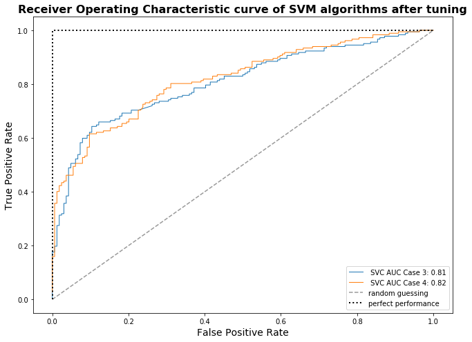

```python
#### import matplotlib.pyplot as plt
%matplotlib inline

from sklearn.metrics import roc_curve, auc
from sklearn.metrics import roc_auc_score

fig=plt.figure(figsize=(10, 7))
all_tpr = []

# Models:

# Case 3
gs_svc_1
probas = gs_svc_1.predict_proba(X_test1)
fpr1, tpr1, thresholds = roc_curve(y_test1, probas[:, 1], pos_label=1)
roc_auc1 = auc(fpr1, tpr1)
current_auc1 = str('%.2f' %roc_auc1)
plt.plot(fpr1,
         tpr1,
         lw=1,
         label= str(' SVC AUC Case 3: ' + current_auc1))

# Case 4
gs_svc_2
probas = gs_svc_2.predict_proba(X_test1)
fpr2, tpr2, thresholds = roc_curve(y_test1, probas[:, 1], pos_label=1)
roc_auc2 = auc(fpr2, tpr2)
current_auc2 = str('%.2f' %roc_auc2)
plt.plot(fpr2,
         tpr2,
         lw=1,
         label= str(' SVC AUC Case 4: ' + current_auc2))


# Plot diagonal
plt.plot([0, 1],
         [0, 1],
         linestyle='--',
         color=(0.6, 0.6, 0.6),
         label='random guessing')

# Plot perfect case
plt.plot([0, 0, 1],
         [0, 1, 1],
         lw=2,
         linestyle=':',
         color='black',
         label='perfect performance')

plt.xlim([-0.05, 1.05])
plt.ylim([-0.05, 1.05])
# plt.xlabel('false positive rate')
# plt.ylabel('true positive rate')
# plt.title('Receiver Operator Characteristic')
plt.legend(loc="lower right")


# Title and labels for axes:
plt.title("Receiver Operating Characteristic curve of SVM algorithms after tuning", fontsize=16, fontweight='bold')
plt.xlabel('False Positive Rate', fontsize=14)
plt.ylabel('True Positive Rate', fontsize=14)

plt.tight_layout()
plt.show()
```